# Wastewater treatment plants contain a conserved core community of bacteria

```r
source("R/functions.R")
```

[output not shown]

```r
source("R/core_community.R")
```

# Data

The source dataset contains all:

```r
identities <- as.character(c(94, 97, 99))
fname_template <- "data/otuXX/seqs_XX_otutable.biom"
filenames <- sapply(identities, function(id) gsub("XX", id, fname_template))

datasets <- lapply(identities, function(identity) LoadData(biompath = filenames[identity],
    mapfpath = "data/mapfile.txt"))
names(datasets) <- paste0("otu", identities)

print(datasets_summary <- data.frame(samples = sapply(datasets, function(identity) sum(nsamples(identity))),
    reads = sapply(datasets, function(identity) sum(sample_sums(identity))),
    OTUs = sapply(datasets, function(identity) sum(ntaxa(identity)))))
```

```
##       samples   reads OTUs
## otu94      48 2374197 2541
## otu97      48 2374197 4586
## otu99      48 2374197 8276
```

### Datasets

```r
subsample_depth <- 40000
# List containing phyloseq objects for core dataset at 94, 97 and 99%
# identity
coreDatasets <- lapply(datasets, function(identity) selectCoreDataset(identity,
    depth = subsample_depth, seed = 1234))
```

[output not shown]

```r
names(coreDatasets) <- paste0("otu", identities)
lapply(coreDatasets, function(identity) printDatasetStats(identity))
```

```
## [1] "number of plants: 13"
##
##       2008 2009
##   AAE    1    1
##   AAW    1    1
##   BJE    1    1
##   EGA    1    1
##   EJB    1    1
##   HJO    1    1
##   HLV    1    1
##   ONE    1    1
##   ONW    1    1
##   RAN    1    1
##   SKI    1    1
##   SOE    1    1
##   VIB    1    1
## [1] 1040000
## [1] "total reads: 1040000"
## [1] "number of plants: 13"
##
##       2008 2009
##   AAE    1    1
##   AAW    1    1
##   BJE    1    1
##   EGA    1    1
##   EJB    1    1
##   HJO    1    1
##   HLV    1    1
##   ONE    1    1
##   ONW    1    1
##   RAN    1    1
##   SKI    1    1
##   SOE    1    1
##   VIB    1    1
## [1] 1040000
## [1] "total reads: 1040000"
## [1] "number of plants: 13"
##
##       2008 2009
##   AAE    1    1
##   AAW    1    1
##   BJE    1    1
##   EGA    1    1
##   EJB    1    1
##   HJO    1    1
##   HLV    1    1
##   ONE    1    1
##   ONW    1    1
##   RAN    1    1
##   SKI    1    1
##   SOE    1    1
##   VIB    1    1
## [1] 1040000
## [1] "total reads: 1040000"
```

```
## $otu94
## [1] "total reads: 1040000"
##
## $otu97
## [1] "total reads: 1040000"
##
## $otu99
## [1] "total reads: 1040000"
```

```r
# List containing phyloseq objects for time-series dataset at 94, 97 and 99%
# id
tseriesDatasets <- lapply(datasets, function(identity) selectAAWDataset(identity,
    depth = subsample_depth))
```

[output not shown]

```r
names(tseriesDatasets) <- paste0("otu", identities)
lapply(tseriesDatasets, function(identity) printDatasetStats(identity))
```

```
## [1] "number of plants: 1"
##
##       2006 2007 2008 2009 2010 2011
##   AAW    2    1    2    2    3    3
## [1] 520000
## [1] "total reads: 520000"
## [1] "number of plants: 1"
##
##       2006 2007 2008 2009 2010 2011
##   AAW    2    1    2    2    3    3
## [1] 520000
## [1] "total reads: 520000"
## [1] "number of plants: 1"
##
##       2006 2007 2008 2009 2010 2011
##   AAW    2    1    2    2    3    3
## [1] 520000
## [1] "total reads: 520000"
```

```
## $otu94
## [1] "total reads: 520000"
##
## $otu97
## [1] "total reads: 520000"
##
## $otu99
## [1] "total reads: 520000"
```

## 1. Core community

## Quantifying the core community

```r
coredataframe <- calcSummaryData(coreDatasets, identities, core_cutoff = 1)

coredata_by_id <- group_by(coredataframe, identities)
summarise(coredata_by_id, coretotalOTUs = sum(taxsum), coreOTUs = sum(taxsum[corestatus ==
    "core"]), percentcorereads = round(readprop[corestatus == "core"] * 100,
    1))
```

```
## Source: local data frame [3 x 4]
##
##   identities coretotalOTUs coreOTUs percentcorereads
## 1         99          7413       77             36.6
## 2         97          4197      100             54.3
## 3         94          2354       86             68.1
```

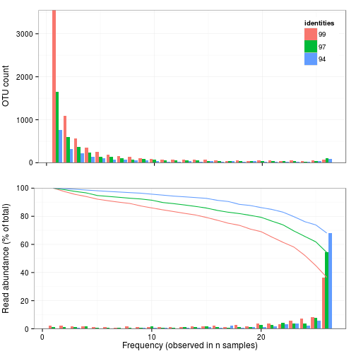

```r
coreplots <- plotCore(coredataframe)
otuplot <- coreplots[[1]]
readsplot <- coreplots[[2]]
print(Figure1 <- grid.arrange(otuplot, readsplot, nrow = 2))
```

```r
pdf(file = "figs/Figure_1_core_otu_conservation40k.pdf")
Figure1
```

```r
dev.off()
```

### Fraction of Transient OTUs (observed no more than 5 times)

```r
filter(coredataframe, numsamples < 6) %.% group_by(identities) %.% summarise(total_OTUs = sum(taxsum),
    percent_reads = round(sum(readprop) * 100, 1))
```

```
## Source: local data frame [3 x 3]
##
##   identities total_OTUs percent_reads
## 1         99       5796           8.9
## 2         97       3003           5.8
## 3         94       1546           2.3
```

### Fraction of Frequently occuring OTUs (observed 20 + times)

```r
filter(coredataframe, numsamples >= 20) %.% group_by(identities) %.% summarise(total_OTUs = sum(taxsum),
    percent_reads = round(sum(readprop) * 100, 1))
```

```
## Source: local data frame [3 x 3]
##
##   identities total_OTUs percent_reads
## 1         99        371          69.1
## 2         97        321          79.3
## 3         94        242          86.2
```

## Cumulative abundance distribution

The distribution of abundances in bacterial communities is uneven - some organisms are abundant some are rare.

Plotting percent cumulative abundance vs. rank ordered OTUs describes this distribution.

```r
cum_abun_plot <- plot_CumulRankAbundance(dataset = coreDatasets[["otu94"]],
    fname = "figs/figure2_cum_abun_plot_94.pdf", dominant_fraction = 0.8)
```

```
## [1] "percent for count of 1: 0.0025"
## [1] "80% cutoff: 65"
## [1] "quantiles for #otus for 80% of reads"
##     0%    25%    50%    75%   100%
##  19.00  48.50  59.50  72.25 134.00
## [1] "abundance of otu at 80th percentile: 0.15 (+- 0.08, n=26)"
## [1] "wrote plot to: figs/figure2_cum_abun_plot_94.pdf"
```

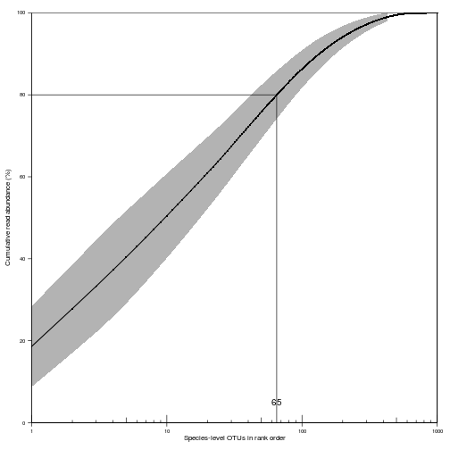

```r
print(cum_abun_plot)
```

### Distribution of abundances per OTU

There is a lot of variation in the abundances but many of the abundant organisms are consitently abundant. These are the organisms that are core. The size of the core will increase as a function of depth for these consistent organisms.

```
## sampled  top 50 OTUs
## 62.9% of the total reads
```

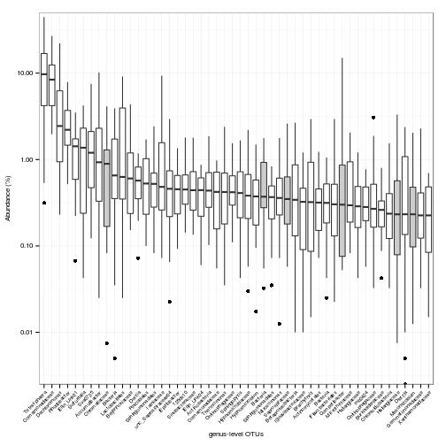

```r
plotTopN(coreDatasets[["otu94"]], topN = 50, plot_filename = "figs/Figure_3_top50_id94_boxplot.pdf",
    core_cutoff = 1)
```

### Temporal stability of a single plant through time

Time series in AAW

What proportion of the core OTUs are core in:

- the two AAW samples used for the core
- all the AAW samples

```r
tsdataframe <- calcSummaryData(tseriesDatasets, identities, core_cutoff = 1)
group_by(tsdataframe, identities) %.% summarise(coretotalOTUs = sum(taxsum),
    coreOTUs = sum(taxsum[corestatus == "core"]), percentcorereads = round(readprop[corestatus ==
        "core"] * 100, 1))
```

```
## Source: local data frame [3 x 4]
##
##   identities coretotalOTUs coreOTUs percentcorereads
## 1         99          2411      329             87.3
## 2         97          1621      254             90.6
## 3         94          1074      190             93.4
```

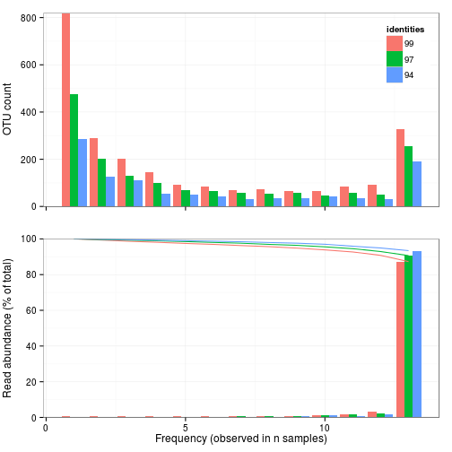

```r
tscoreplot <- plotCore(tsdataframe)
tsotuplot <- tscoreplot[[1]]
tsreadsplot <- tscoreplot[[2]]
print(tscoreplot <- grid.arrange(tsotuplot, tsreadsplot, nrow = 2))
```

```r
pdf(file = "figs/Figure_S2_aawtimeseries_core_conservation_40k.png")
tscoreplot
```

```r
dev.off()
```

### Binning of OTUs by observation frequency and frequency of high-abundance

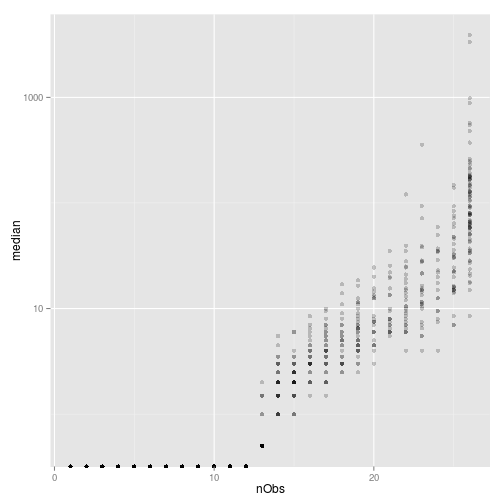

```r
dataset <- coreDatasets[["otu94"]]
core_prop <- 1

dominant <- sapply(sample_names(dataset), function(samplename) fill_ha_data(dataset,
    samplename))
row.names(dominant) <- taxa_names(dataset)

observed <- as.data.frame(otu_table(transform_sample_counts(dataset, function(x) ifelse(x >
    0, 1, 0))))

summary.df <- data.frame(OTU = taxa_names(dataset), nHA = apply(dominant, 1,
    sum), nObs = apply(observed, 1, sum), median = apply(otu_table(dataset),
    1, median), geomean = apply(otu_table(dataset), 1, function(x) round(exp(mean(log(x))),
    1)), max = apply(otu_table(dataset), 1, max), min = apply(otu_table(dataset),
    1, min), n1per = apply(otu_table(dataset), 1, function(x) sum(x > 400)))
# how does median relate to nHA and nObs?
ggplot(summary.df, aes(nObs, median)) + geom_point(alpha = 0.2) + scale_y_log10()
```

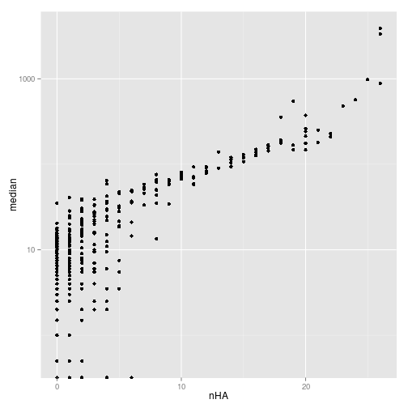

```r
ggplot(summary.df, aes(nHA, median)) + geom_point() + scale_y_log10()
```

These plots are the justification for having nHA > 10 as the cutoff for significance.

## Figure 4

Sets up the empty Figure 4 plot. The data was filled manually using Inkscape.

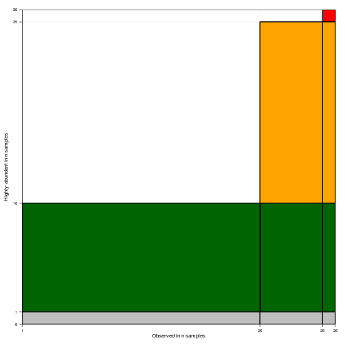

```r
summary.df <- mutate(summary.df, group = factor(cut(nHA, breaks = c(-1, 0, 9,
    25, 26), labels = c("4", "3", "2", "1")), levels = 1:4), Obsclass = cut(nObs,
    breaks = c(0, 19, 25, 26), labels = c("ob1", "ob20", "ob26")))
summary.df <- cbind(summary.df, as.data.frame(otu_table(dataset)))
summary.df <- arrange(summary.df, desc(nHA), desc(nObs), desc(median))
# Empty plot
print(Figure4 <- plotFigure4())
```

```r
ggsave(filename = "figs/Figure4.pdf", plot = Figure4, width = 8, height = 8,
    units = "cm")
```